# MA615 PROJECT1

SIMON WANG

9/24/2020

## Download Data

Because these txt files have different column names, the initial data is separated into 5 data frames. Take 1987 - 1998 as example. Their original column names are:

```r
colnames(merge.data1)
```

```
##  [1] "YY"   "MM"   "DD"   "hh"   "WD"   "WSPD" "GST"  "WVHT" "DPD"  "APD"
## [11] "MWD"  "BAR"  "ATMP" "WTMP" "DEWP" "VIS"
```

Combine its date variables into DATE, and time variables into TIME, Add an new variable as MONTH for future group.

```r
colnames(merge.data1)
```

```
##  [1] "DATE"  "MONTH" "TIME"  "WD"    "WSPD"  "GST"   "WVHT"  "DPD"   "APD"
## [10] "MWD"   "BAR"   "ATMP"  "WTMP"  "DEWP"  "VIS"
```

Do the same with the next 4 data frames.

## Combine data frames.

After change the date and time variables, we can combine 5 data frames into 3. Print the column names to find the difference.

```
##  [1] "DATE"  "MONTH" "TIME"  "WD"    "WSPD"  "GST"   "WVHT"  "DPD"   "APD"
## [10] "MWD"   "BAR"   "ATMP"  "WTMP"  "DEWP"  "VIS"
```

```
##  [1] "DATE"  "MONTH" "TIME"  "WD"    "WSPD"  "GST"   "WVHT"  "DPD"   "APD"
## [10] "MWD"   "BAR"   "ATMP"  "WTMP"  "DEWP"  "VIS"   "TIDE"
```

```
##  [1] "DATE"  "MONTH" "TIME"  "WDIR"  "WSPD"  "GST"   "WVHT"  "DPD"   "APD"
## [10] "MWD"   "PRES"  "ATMP"  "WTMP"  "DEWP"  "VIS"   "TIDE"
```

From the definition on NOAA National Data Buoy Center Website, we find the “BAR” is the historic name of “PRES”. Change the column name for data before 2007.

```r
names(data_87_99)[names(data_87_99)=="BAR"]="PRES"
names(data_00_06)[names(data_00_06)=="BAR"]="PRES"
```

Add NA for TIDE, WDIR and WD to the data frame as a missing value to make their names as each other. Then combine the data frames into one.

```r
data_87_19 <- rbind(data_87_99,data_00_06,data_07_19)
```

Convert the data from character into numeric.

```r
str(data_87_19)
```

```
## 'data.frame':    276411 obs. of  17 variables:
##  $ DATE : Date, format: "1987-01-01" "1987-01-01" ...
##  $ MONTH: Date, format: "1987-01-01" "1987-01-01" ...
##  $ TIME : num  0 3600 7200 10800 14400 18000 21600 25200 28800 32400 ...
##  $ WD   : num  290 290 290 300 290 340 10 10 20 20 ...
##  $ WDIR : num  NA NA NA NA NA NA NA NA NA NA ...
##  $ WSPD : num  8 7 6 6 5 6 5 4 7 5 ...
##  $ GST  : num  10 8 8 7 6 7 6 6 8 6 ...
##  $ WVHT : num  2.7 2.4 2.5 2.6 2.7 2.4 2.4 2.6 2.5 2.5 ...
##  $ DPD  : num  11.1 10 11.1 11.1 12.5 14.3 12.5 12.5 12.5 12.5 ...
##  $ APD  : num  8.6 8 8.3 8.6 8.7 8.4 8.8 9.5 9.2 9.1 ...
##  $ MWD  : num  999 999 999 999 999 999 999 999 999 999 ...
##  $ PRES : num  1024 1024 1024 1024 1025 ...
##  $ ATMP : num  2.8 2 1.6 1.3 1 0.7 0.7 0.5 0.4 0.4 ...
##  $ WTMP : num  5.9 5.9 5.9 6 5.9 5.9 5.9 5.9 5.9 5.9 ...
##  $ DEWP : num  999 999 999 999 999 999 999 999 999 999 ...
##  $ VIS  : num  99 99 99 99 99 99 99 99 99 99 ...
##  $ TIDE : chr  NA NA NA NA ...
```

There are some data like “9999”, “999”, “99”, which seems impossible value. They are actually missing value. Replace them with NA.

```r
summary(data_87_19,na.rm = TRUE)
```

```
##       DATE                MONTH                 TIME             WD
##  Min.   :1987-01-01   Min.   :1987-01-01   Min.   :    0   Min.   :  0.0
##  1st Qu.:1995-03-23   1st Qu.:1995-04-01   1st Qu.:21000   1st Qu.:136.0
##  Median :2003-06-28   Median :2003-07-01   Median :42600   Median :224.0
##  Mean   :2003-07-08   Mean   :2003-07-08   Mean   :42451   Mean   :270.4
##  3rd Qu.:2011-07-04   3rd Qu.:2011-07-01   3rd Qu.:64200   3rd Qu.:299.0
##  Max.   :2019-12-31   Max.   :2020-01-01   Max.   :85800   Max.   :999.0
##                                                            NA's   :107545
##       WDIR             WSPD             GST             WVHT
##  Min.   :  1.0    Min.   : 0.000   Min.   : 0.00   Min.   : 0.000
##  1st Qu.:125.0    1st Qu.: 3.700   1st Qu.: 4.40   1st Qu.: 0.400
##  Median :204.0    Median : 5.700   Median : 6.80   Median : 0.660
##  Mean   :197.7    Mean   : 9.788   Mean   :11.14   Mean   : 2.095
##  3rd Qu.:281.0    3rd Qu.: 8.600   3rd Qu.:10.40   3rd Qu.: 1.090
##  Max.   :999.0    Max.   :99.000   Max.   :99.00   Max.   :99.000
##  NA's   :168866
##       DPD              APD              MWD             PRES
##  Min.   : 0.000   Min.   : 0.000   Min.   :  0.0   Min.   : 964.6
##  1st Qu.: 4.550   1st Qu.: 3.900   1st Qu.:122.0   1st Qu.:1010.2
##  Median : 7.690   Median : 4.800   Median :999.0   Median :1015.7
##  Mean   : 9.473   Mean   : 6.186   Mean   :700.9   Mean   :1051.8
##  3rd Qu.:10.000   3rd Qu.: 5.960   3rd Qu.:999.0   3rd Qu.:1021.2
##  Max.   :99.000   Max.   :99.000   Max.   :999.0   Max.   :9999.0
##
##       ATMP             WTMP             DEWP            VIS
##  Min.   :-19.70   Min.   : -1.80   Min.   :-24.9   Min.   : 0.00
##  1st Qu.:  3.60   1st Qu.:  5.30   1st Qu.:  6.7   1st Qu.:99.00
##  Median :  9.70   Median : 10.30   Median : 20.6   Median :99.00
##  Mean   : 13.87   Mean   : 54.43   Mean   :491.7   Mean   :92.98
##  3rd Qu.: 16.70   3rd Qu.: 16.50   3rd Qu.:999.0   3rd Qu.:99.00
##  Max.   :999.00   Max.   :999.00   Max.   :999.0   Max.   :99.00
##
##      TIDE
##  Length:276411
##  Class :character
##  Mode  :character
##
##
##
##
```

```r
summary(data_87_19,na.rm = TRUE)
```

```
##       DATE                MONTH                 TIME             WD
##  Min.   :1987-01-01   Min.   :1987-01-01   Min.   :    0   Min.   :  0.0
##  1st Qu.:1995-03-23   1st Qu.:1995-04-01   1st Qu.:21000   1st Qu.:127.0
##  Median :2003-06-28   Median :2003-07-01   Median :42600   Median :211.0
##  Mean   :2003-07-08   Mean   :2003-07-08   Mean   :42451   Mean   :197.8
##  3rd Qu.:2011-07-04   3rd Qu.:2011-07-01   3rd Qu.:64200   3rd Qu.:280.0
##  Max.   :2019-12-31   Max.   :2020-01-01   Max.   :85800   Max.   :360.0
##                                                            NA's   :122835
##       WDIR             WSPD             GST             WVHT
##  Min.   :  1.0    Min.   : 0.000   Min.   : 0.0    Min.   :0.000
##  1st Qu.:124.0    1st Qu.: 3.600   1st Qu.: 4.3    1st Qu.:0.400
##  Median :203.0    Median : 5.500   Median : 6.6    Median :0.650
##  Mean   :195.8    Mean   : 6.079   Mean   : 7.4    Mean   :0.864
##  3rd Qu.:281.0    3rd Qu.: 8.100   3rd Qu.: 9.8    3rd Qu.:1.060
##  Max.   :360.0    Max.   :25.700   Max.   :32.4    Max.   :9.100
##  NA's   :169114   NA's   :11033    NA's   :11295   NA's   :3467
##       DPD              APD              MWD              PRES
##  Min.   : 0.000   Min.   : 0.000   Min.   :  0.0    Min.   : 964.6
##  1st Qu.: 4.550   1st Qu.: 3.900   1st Qu.: 78.0    1st Qu.:1010.2
##  Median : 7.690   Median : 4.780   Median : 94.0    Median :1015.7
##  Mean   : 7.378   Mean   : 5.007   Mean   :124.3    Mean   :1015.5
##  3rd Qu.:10.000   3rd Qu.: 5.900   3rd Qu.:129.0    3rd Qu.:1021.1
##  Max.   :25.000   Max.   :12.100   Max.   :360.0    Max.   :1045.8
##  NA's   :6319     NA's   :3467     NA's   :182225   NA's   :1117
##       ATMP              WTMP            DEWP             VIS
##  Min.   :-19.700   Min.   :-1.80   Min.   :-24.90   Min.   : 0.00
##  1st Qu.:  3.600   1st Qu.: 5.10   1st Qu.: -0.50   1st Qu.: 8.10
##  Median :  9.700   Median : 9.80   Median :  7.00   Median : 9.40
##  Mean   :  9.671   Mean   :10.49   Mean   :  6.28   Mean   :12.48
##  3rd Qu.: 16.700   3rd Qu.:15.70   3rd Qu.: 14.50   3rd Qu.:11.60
##  Max.   : 32.100   Max.   :27.80   Max.   : 26.10   Max.   :36.00
##  NA's   :1172      NA's   :12288   NA's   :135148   NA's   :257172
##      TIDE
##  Length:276411
##  Class :character
##  Mode  :character
##
##
##
##
```

Save data as BuoyData.Rdata

```r
save(data_87_19,file='BuoyData.Rdata')
```

## Data Select

Remove rows with NA, group the data by day(month), calculate the mean value of variables by day(month).

```r
tmpdata  <-  na.omit(tmpdata)
planes3 <-  group_by(tmpdata, DATE)
delay3  <-  summarise(planes3, WSPD = mean(WSPD, na.rm = TRUE),
                      GST = mean(GST, na.rm = TRUE),
                      WVHT = mean(WVHT, na.rm = TRUE),
                      DPD = mean(DPD, na.rm = TRUE),
                      APD = mean(APD, na.rm = TRUE),
                      PRES = mean(PRES, na.rm = TRUE),
                      ATMP = mean(ATMP, na.rm = TRUE),
                      WTMP = mean(WTMP, na.rm = TRUE))
```

Delay3 is the data frame grouped by day.

```r
head(delay3,n=3)
```

```
## # A tibble: 3 x 9
##   DATE        WSPD   GST  WVHT   DPD   APD  PRES  ATMP  WTMP
##   <date>     <dbl> <dbl> <dbl> <dbl> <dbl> <dbl> <dbl> <dbl>
## 1 1987-01-01   4    5.25  2.08 11.9   8.44 1025.  1.7   5.89
## 2 1987-01-02  11.7 14.6   2.76  9.46  6.87 1005.  3.06  5.84
## 3 1987-01-03  10.0 12.3   1.92 10.4   6.08  999. -1.12  5.72
```

```r
planes4 <-  group_by(tmpdata, MONTH)
delay4  <-  summarise(planes4, WSPD = mean(WSPD, na.rm = TRUE),
                      GST = mean(GST, na.rm = TRUE),
                      WVHT = mean(WVHT, na.rm = TRUE),
                      DPD = mean(DPD, na.rm = TRUE),
                      APD = mean(APD, na.rm = TRUE),
                      PRES = mean(PRES, na.rm = TRUE),
                      ATMP = mean(ATMP, na.rm = TRUE),
                      WTMP = mean(WTMP, na.rm = TRUE))
```

Delay4 is the data frame grouped by month.

```r
head(delay4,n=3)
```

```
## # A tibble: 3 x 9
##   MONTH       WSPD   GST  WVHT   DPD   APD  PRES   ATMP  WTMP
##   <date>     <dbl> <dbl> <dbl> <dbl> <dbl> <dbl>  <dbl> <dbl>
## 1 1987-01-01  7.48  9.24 0.890  6.07  4.50 1010.  1.75   5.33
## 2 1987-02-01  7.41  9.31 1.11   7.71  5.36 1011. -2.23   3.69
## 3 1987-03-01  6.19  7.67 0.907  6.68  4.94 1019. -0.480  2.40
```

## Correlation between different variables

We make plot correlation between these variables.

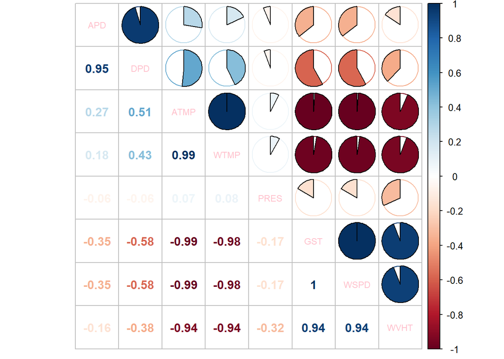

```r
corrplot(corr = res_cor,order = "AOE",type="upper",method="pie",tl.pos = "d",tl.cex = 0.75,tl.col = "pink")
corrplot(corr = res_cor,add=TRUE, type="lower", method="number",order="AOE",diag=FALSE,tl.pos="n", cl.pos="n")
```

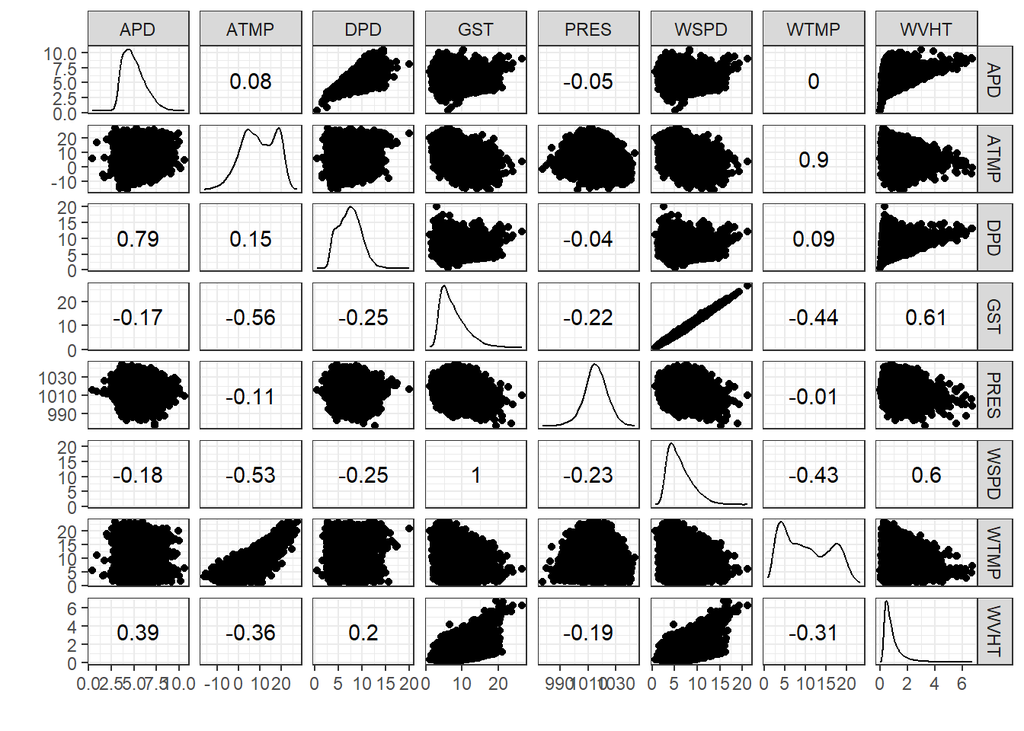

Plot the relationship between ATMP and WSPD, GST, WVHT and DPD with ggplot.

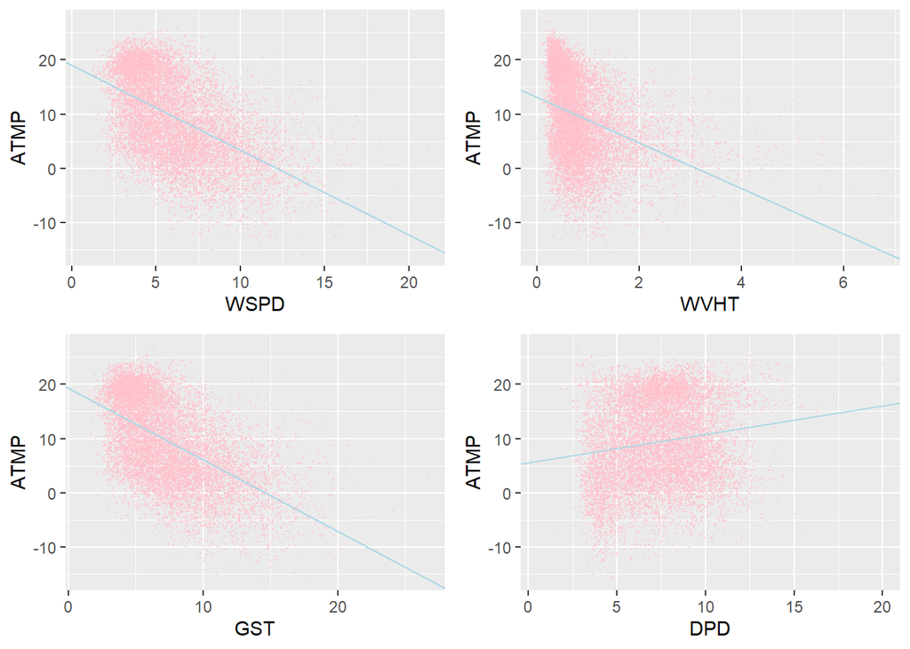

# Time and Temperature

Plot the Date and Temperature, add smooth line to show the trends.

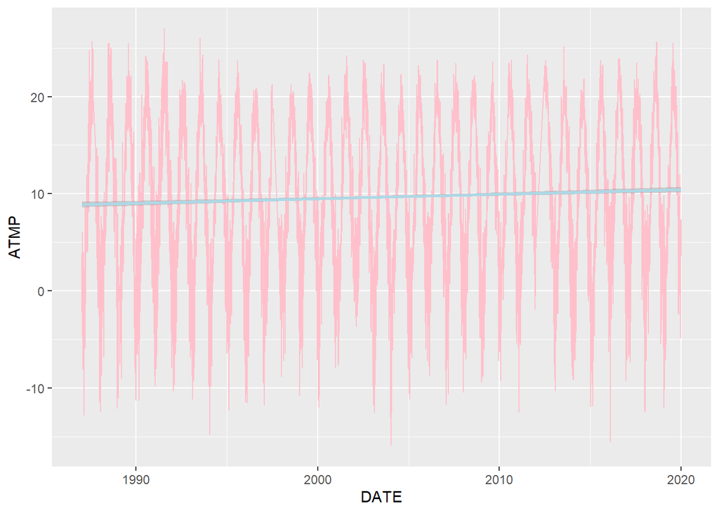

Plot a heatmap to show the trends of temperature with DATE.

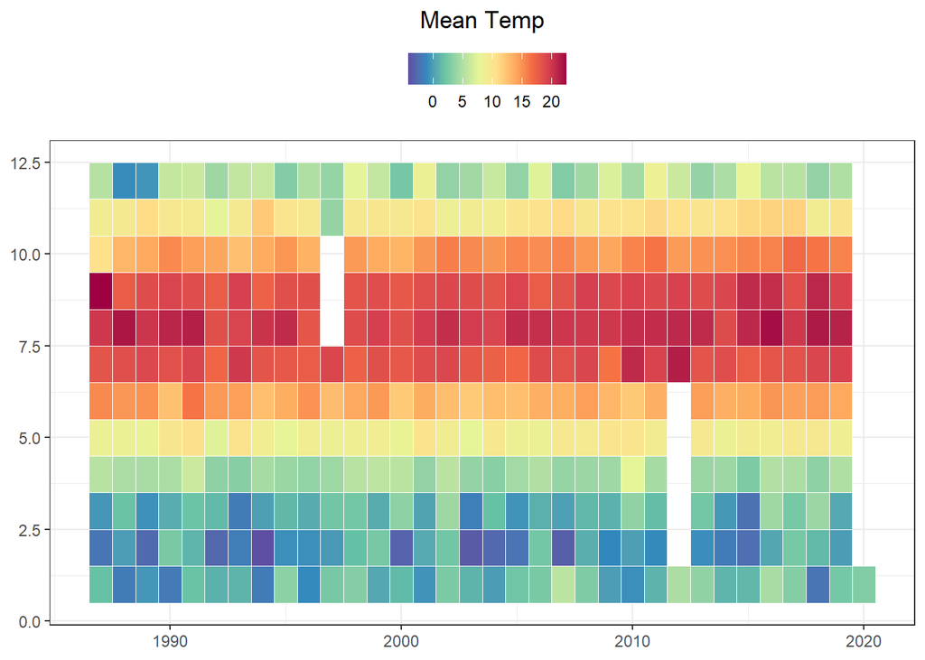

Do regression of Temperature of DATE:

```r
fit_date<-lm(data=delay3, ATMP~DATE)
summary(fit_date)
```

```
##
## Call:
## lm(formula = ATMP ~ DATE, data = delay3)
##
## Residuals:
##     Min      1Q  Median      3Q     Max
## -25.942  -5.951  -0.201   7.068  18.721
##
## Coefficients:
##              Estimate Std. Error t value Pr(>|t|)
## (Intercept) 6.389e+00  2.883e-01   22.16   <2e-16 ***
## DATE        2.402e-04  2.219e-05   10.82   <2e-16 ***
## ---
## Signif. codes:  0 '***' 0.001 '**' 0.01 '*' 0.05 '.' 0.1 ' ' 1
##
## Residual standard error: 7.829 on 10657 degrees of freedom
## Multiple R-squared:  0.01087,    Adjusted R-squared:  0.01078
## F-statistic: 117.2 on 1 and 10657 DF,  p-value: < 2.2e-16
```

```r
coef(fit_date)
```

```
##  (Intercept)         DATE
## 6.3887626487 0.0002401496
```

We can see the slop is small, but the p-value shows this coefficient is significantly different from zero!

## Conclusion

The temperature is raising by time!